# on-p-values

**Uma investigação sobre a taxa de falsos positivos e a má interpretação dos valores P**

[*An investigation of the false discovery rate and the misinterpretation of p-values*](https://doi.org/10.1098/rsos.140216)

**LGN 5822 - Statistical Genetics I: Foundations**

**Discentes**: Ana Matiussi, Paula Cardoso e Thiago Ludwig

**Docente**: Prof. Dr. Saulo Chaves

[figure not shown]

[figure not shown]

# O Problema Central

## O Problema Central

- **`Crise de reprodutibilidade na ciência`**: muitos resultados publicados não consegue ser replicado por outros pesquisadores.
- **`Causas principais`**: Erro na interpretação do p-valor e, consequentemente, a alta taxa de **`falsas descobertas`**.

Ao definir “estatisticamente significativo” como qualquer coisa abaixo de $\small p=0,05$, tem pelo menos 30% de estar errado (Colquhoun, 2014).

# Analogia: Teste de Triagem

## Ex: teste de rastreamento de comprometimento cognitivo leve (CCL)

- Das 100 pessoas que com a CCL, 80 (80%) serão detectadas e 20 não. Então, no total, 495 + 80 = 575 pessoas terão teste positivo, das quais 495 são falsos positivos.

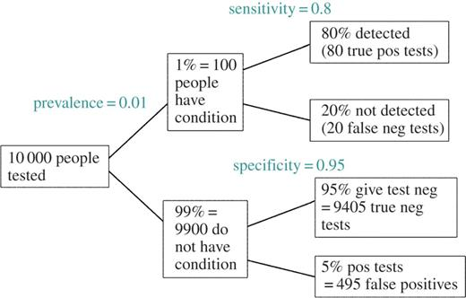

`Diagrama de árvore para ilustrar a taxa de falsos positivos em testes de triagem.`

- **`Conclusão`**: Um teste de triagem pode parecer confiável no papel, mas quando aplicado a uma população onde a doença é rara, a maioria dos resultados positivos será falsa.

# O problema do teste de significância

## Mesma lógica se aplica aos Testes de Significância

- Se apenas 10% das hipóteses testadas são verdadeiras (prevalência real de efeito = 10%) e o poder do teste é 80%, então, entre os resultados significativos, a proporção de falsos positivos é de 36% (muito acima dos 5% que muitos supõem).

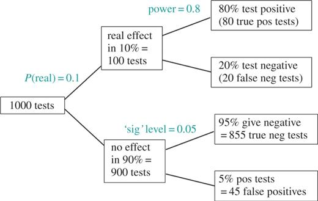

`Diagrama de árvore para ilustrar a taxa de falsos positivos em testes de significância.`

- **`Conclusão`**: Declarar uma descoberta com base em $\small p = 0,05$ parece seguro, mas mesmo em um **`cenário idealizado`** (ex: condições estatísticas respeitadas, $\small \varepsilon \sim \mathcal{N}(0,\sigma^2)$, aleatorização sem viés, etc), a taxa de falsos positivos ainda é alta.

# O efeito da inflação

## Efeito do baixo poder estatístico

- **`Problema`**: Quando um estudo tem baixo poder estatístico, ele não só tem dificuldade em detectar efeitos reais, como também, nas raras vezes em que detecta, exagera o tamanho do efeito encontrado.

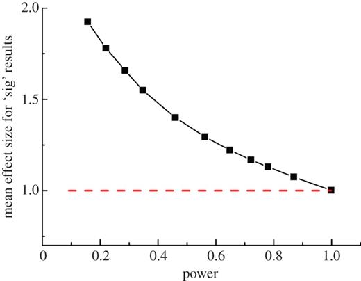

`A diferença média entre as médias para todos os testes que apresentaram p ≤ 0,05.`

- **`Conclusão`**: Quanto menor o poder, maior o erro e maior o exagero do efeito. Um poder ideal é geralmente considerado 80%.

# Regra dos três sigmas

## Regra dos três sigmas ($3\sigma$)

- Solução proposta pelo autor para evitar o problema dos 30% de erros $\rightarrow$ vem da estatística e se baseia na distância em relação à média de uma distribuição normal.

**Dois sigmas**

- equivale a $\small p = 0,05$;
- corresponde ao critério tradicional;
- pode levar a cerca de 30% de erros.

**Três sigmas**

- equivale a $\small p \approx 0,001$;
- é um critério mais rigoroso;
- reduz a taxa de falsas descobertas para 1,84%.
- **`Conclusão`**: A regra dos três sigmas é simplesmente trocar o $\small p=0,05$ pelo $\small p \approx 0,001$, sendo um critério mais rigoroso para reduzir os falsos positivos.

# Conclusão

## Conclusão

- **`O uso do`** $\small p = 0,05$ como critério de descoberta científica é falho e contribui para a crise de reprodutibilidade na ciência.
- **`Independentemente do método`**, a matemática mostra que pelo menos 30% dos resultados publicados como descobertas são simplesmente falsos;
- **`A solução`** é adotar critérios mais rigorosos, como $\small p < 0,001$;
- **`Evitar`** “significativo” ou “não significativo”, pois é enganosa.